# Manual de Projetos

#### 4 · Diagrama de Classes

O recorte que este fio toca — não o sistema inteiro. Visibilidade em `+ - # ~`, `<<enumeration>>` para o conjunto fechado de valores, multiplicidade nas associações:

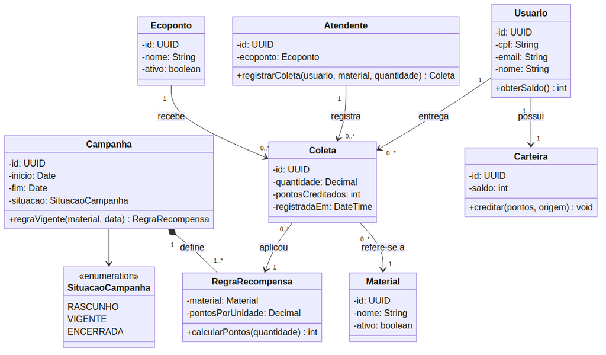

**Três decisões de modelagem que o desenho torna visíveis, e que valem mais que o desenho:**

**`Coleta` guarda `pontosCreditados`, e não apenas a quantidade.** Poderia recalcular a partir da regra — e estaria errado. A campanha muda; o que foi creditado ontem não pode mudar hoje. Guardar o resultado congela o passado.

**`Coleta` aponta para a `RegraRecompensa` que aplicou.** Sem essa seta, ninguém consegue explicar seis meses depois por que uma entrega valeu 40 pontos e outra igual valeu 25.

**A losango cheia entre `Campanha` e `RegraRecompensa` é composição, não agregação.** Uma regra não existe fora da campanha que a define; apagada a campanha, as regras vão junto. A escolha entre `*--` e `o--` não é estética.

> **E o que este diagrama deliberadamente não tem.** Nada de `getters` e `setters`, nada de campos de auditoria, nenhuma classe de infraestrutura. O `§2.4.4` é explícito: **modele a arquitetura e o fluxo principal, não superdetalhe** — detalhe excessivo aqui vira viés e burocracia na implementação.

#### 5 · Diagrama de Sequência

Nem toda User Story merece um. Esta merece por dois dos gatilhos do `§2.4.5`: há **regra de negócio com cálculo** e há **uma operação que pode ser repetida pelo usuário** — o atendente que clica de novo depois de a conexão cair.

Mensagens no formato do capítulo: `Ação no infinitivo: nomeDoMetodo(parametros)`, e retornos como `Ação no infinitivo: TipoDoRetorno`.

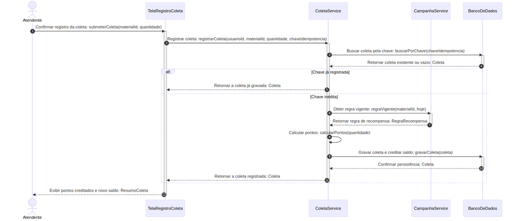

**O `alt` é o diagrama inteiro.** Ele responde à pergunta que nenhum artefato anterior conseguiu fazer: *o que acontece quando o atendente confirma duas vezes?* A resposta é a `chaveIdempotencia`, gerada quando a tela abre e enviada junto com o registro. Se a chave já existe, o sistema devolve a coleta que já gravou em vez de gravar outra.

**Repare de onde vem o ecoponto.** Ele **não** é parâmetro da chamada — vem do token do atendente autenticado. Se fosse parâmetro, um atendente poderia registrar coleta em ecoponto alheio, e a segregação de acesso do contrato (`RNF-04`) viraria uma sugestão. **Um diagrama de sequência mostra não só o que é passado, mas o que deliberadamente não é.**

E note o que o desenho **não** tem: nada de HTTP, JSON, nomes de tabela ou de framework. As participantes são papéis do domínio.

#### 6 · Modelo físico e máquina de estado

Aqui está o argumento central do `§2.4.6`, num caso concreto. O cenário 5 do critério de aceite exige que uma repetição não credite em dobro. **Essa garantia não mora em nenhuma classe** — mora numa restrição de unicidade no banco, e o Diagrama de Classes não tem onde desenhar uma restrição.

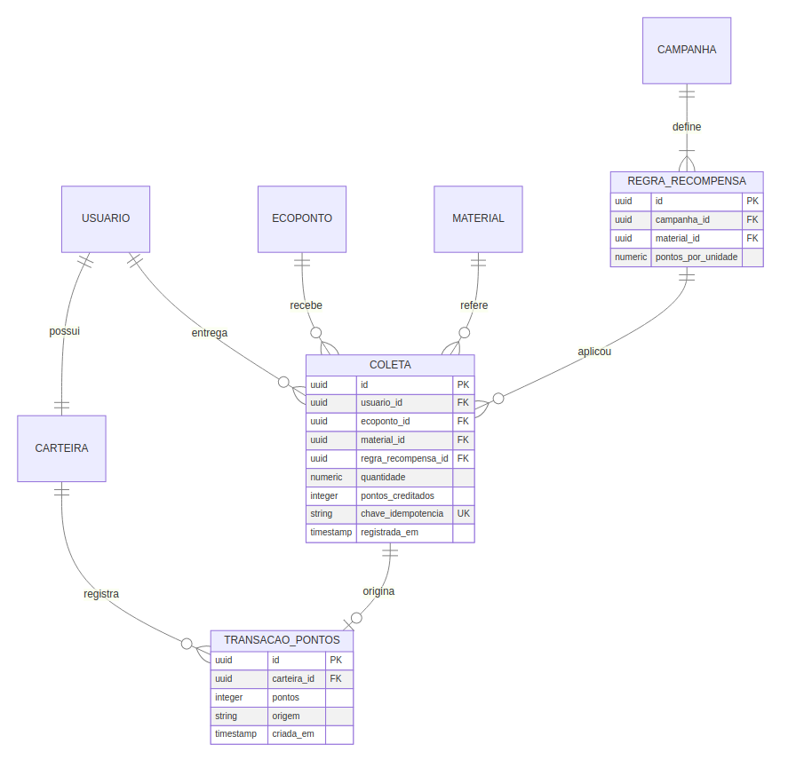

**Três regras que só existem porque alguém desenhou o modelo físico:**

**`chave_idempotencia` é `UK`.** É a linha que implementa o cenário 5. Sem ela, a garantia de não-duplicidade dependeria de o programador lembrar de checar — e “lembrar” não é um mecanismo.

**`pontos_creditados` é `integer`; `quantidade` e `pontos_por_unidade` são `numeric`.** Pontos são inteiros, e a multiplicação de decimais tem de ser feita em aritmética decimal, com arredondamento explícito, **nunca em ponto flutuante**. Essa decisão aparece no tipo da coluna e em lugar nenhum antes dele. É exatamente o tipo de coisa que se descobre tarde e caro.

**`TRANSACAO_PONTOS` existe, e o saldo da carteira é derivado dela.** Guardar só um número em `carteira.saldo` seria mais simples e impossível de auditar: quando o saldo divergir — e vai divergir — não haveria como saber qual crédito faltou. O saldo é a soma das transações.

**Máquina de estado.** A campanha tem ciclo de vida com regra por transição, então ganha diagrama — não um parágrafo:

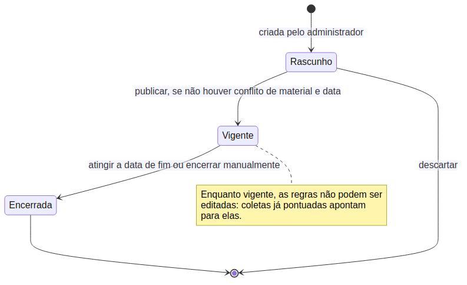

A transição `Rascunho → Vigente` carrega a regra mais delicada do modelo: **para um mesmo material, numa mesma data, só pode haver uma regra em vigor.** Campanhas podem coexistir; o que não pode é duas delas premiarem o mesmo material no mesmo dia, senão a conversão fica ambígua. Uma entidade com mais de dois estados e uma regra por transição pede máquina de estado.

#### 7 · Visão arquitetural — C4

**Nível 1 — Contexto.** Quem usa e com o que o sistema conversa. Nada de tecnologia:

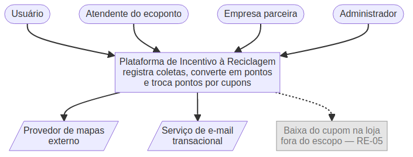

**A caixa cinza é a disciplina que torna um diagrama de contexto útil.** Ela desenha o que está deliberadamente **fora** da fronteira. O sistema emite o código do cupom e a responsabilidade dele termina ali — quem honra o cupom no balcão da loja é a loja. Sem essa caixa, todo mundo assume que “o sistema cuida do cupom” e a divergência aparece na entrega.

**Nível 2 — Contêiner.** Agora sim, tecnologia — a contratada em `RNF-03`, que é a pilha padrão da IDE:

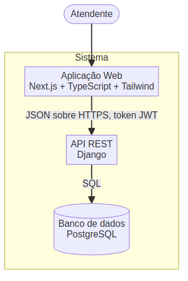

**Nível 3 — Componente.** Só vale a pena para o módulo que concentra regra de negócio. Aqui seria o de coleta e pontuação: o serviço de coleta, o de campanha e o de carteira, com a dependência entre eles. Para o módulo institucional, que serve conteúdo estático, desenhar componentes seria burocracia.

**Nível 4 — Código.** **Não desenhe.** O `§2.4.7` é direto quanto a isso, e a razão é prática: o nível 4 é a classe e o método, que já estão no código, mudam a cada sprint, e nenhum diagrama acompanha. Um nível 4 desatualizado é pior que nenhum.

**Diagrama de implantação.** É o que força a pergunta que ninguém gosta de fazer: **quem paga a conta depois que o contrato acabar?** No Impacto Ambiental o custo recorrente de hospedagem é responsabilidade contratual do cliente, e o provedor de mapas continuava sem dono definido no momento da proposta. Se essa pergunta não estiver em um diagrama, ela não está em lugar nenhum.

#### 8 · Documentação como código — o ADR

O diagrama mostra a `chave_idempotencia`. Ele é incapaz de mostrar **por que** ela foi escolhida em vez das alternativas — e é essa a informação que se perde primeiro. No modelo mínimo do `§2.4.8`:

```markdown
# ADR-001 — Idempotência do registro de coleta por chave enviada pelo cliente

**Status:** Aceito
**Data:** AAAA-MM-DD

## Contexto
O atendente registra coletas em balcão, muitas vezes em rede instável. Uma
confirmação repetida após queda de conexão não pode creditar pontos duas vezes
(critério de aceite, cenário 5 da US001).

## Decisão
A tela gera uma chave de idempotência ao abrir e a envia no registro. A coluna
tem restrição de unicidade; uma chave repetida devolve a coleta já gravada.

## Alternativas rejeitadas
- **Bloquear o botão após o primeiro clique** — não resolve: a falha acontece
  entre o envio e a resposta, e o segundo clique vem de um recarregamento.
- **Deduplicar por usuário + material + quantidade + janela de tempo** — rejeita
  entregas legítimas: a mesma pessoa pode entregar o mesmo material duas vezes
  no mesmo dia.

## Consequências
Toda tela de registro passa a gerar e enviar a chave. Em troca, a repetição
deixa de ser um risco e o botão de confirmar pode ser clicado sem medo.
```

**Sem esse documento, a segunda alternativa volta.** Ela é mais simples, parece razoável, e alguém vai propô-la daqui a três meses. Um diagrama transfere a arquitetura; um ADR transfere o julgamento — e é o artefato mais diretamente antirrotatividade de todos.

#### 9 · A cadeia fechada

Do contrato à Issue, sem elo solto:

| Artefato | Instância |
| --- | --- |
| Requisito contratado | `RF-ATD-02` a `RF-ATD-05` |
| Matriz de Requisitos | 5 linhas, módulos Atendente / Coleta / Pontuação |
| User Story | `US001`, 5 cenários BDD, INVEST validado |
| User Flow | `UF001`, 3 losangos, todos os cenários com caminho |
| Diagrama de Classes | 8 classes, 1 enumeração |
| Diagrama de Sequência | 1 `alt` — a idempotência |
| Modelo físico | `chave_idempotencia UK`, pontos em inteiro, saldo derivado |
| Máquina de estado | Ciclo de vida da campanha |
| C4 | Contexto e contêiner |
| ADR | `ADR-001` |
| **Issue** | *“Registrar coleta no ecoponto”*, fechando `RF-ATD-03` |

**A Issue rastreia até um `RF`, e o `RF` rastreia até uma linha do contrato.** É essa a propriedade que o capítulo inteiro existe para garantir: qualquer pessoa consegue perguntar *“por que estamos construindo isto?”* e chegar a uma resposta escrita.

**E os anti-padrões do `§2.4.9` que este exercício evitou:**

[output not shown]

> **O que o membro leva daqui.** Nenhum destes artefatos foi criado porque o processo mandava. Cada um respondeu a uma pergunta que os anteriores não conseguiam: a MRF diz *o que foi contratado*, a User Story diz *para quem e por quê*, o User Flow diz *por onde se passa*, as classes dizem *com que abstrações*, a sequência diz *em que ordem e o que acontece quando falha*, o modelo físico diz *quais regras o banco garante*, o C4 diz *onde isso roda*, e o ADR diz *o que foi rejeitado*. **Se um artefato não está respondendo a nenhuma pergunta nova, ele não precisava ter sido feito.**

## 2.5 Padrões e convenções de desenvolvimento

Os capítulos anteriores definiram **como o trabalho é organizado** (*capítulo 2.2*), **como a experiência do usuário é projetada** (*capítulo 2.3*) e **como o sistema é modelado** (*capítulo 2.4*). Resta a última pergunta da cadeia, e a mais próxima do teclado: **como o código em si deve ser escrito.**

Este capítulo reúne os padrões e convenções adotados pela **IDE JR** — e, em larga medida, pela própria comunidade de computação — que todo desenvolvedor deve ter em mente ao trabalhar em um projeto da empresa. Eles servem de balizamento do desenvolvimento do produto, com dois objetivos práticos: **manter a organização do projeto e facilitar a compreensão entre os pares.**

Algumas dessas convenções admitem mais de uma resposta correta, e a resposta certa varia conforme a linguagem, o framework e a natureza do projeto. Isso não as torna opcionais:

> **REGRA GERAL DO CAPÍTULO —** A escolha do padrão é decisão da equipe, tomada no início do projeto e registrada por escrito. Uma vez escolhido, **o cumprimento do padrão não é facultativo**. Um projeto com três dialetos de código não possui flexibilidade — possui inconsistência.

Vale explicitar o motivo, porque ele não é estético. A IDE opera com equipes pequenas, membros majoritariamente em semestres iniciais e **rotatividade alta entre semestres**. Convenção compartilhada é o mecanismo mais barato de transferência de conhecimento que existe: é o que permite a alguém abrir um arquivo que nunca viu, escrito por alguém que já saiu da empresa, e compreendê-lo sem arqueologia.

**Código é lido muitas vezes mais do que é escrito.** Escreva para quem vai lê-lo depois — inclusive para o membro que entra no próximo semestre e não participou de nenhuma decisão deste projeto.

### 2.5.1 Nomenclatura e formatação

Nomear bem é a forma mais barata de documentar. Um identificador claro elimina a necessidade do comentário que o explicaria.

Para padrões específicos de uma linguagem, consulte o [Google Code Styles](https://google.github.io/styleguide/). As convenções por stack utilizada na IDE estão detalhadas no **item 2.5.3**.

| Elemento | Convenção | Exemplo |
| --- | --- | --- |
| **Classe** | `PascalCase`. Nome claro e significativo, representando **um** conceito do domínio. | `UserService`; `HomePageController`; `InputParser` |
| **Métodos** | `camelCase`. Descrevem uma ação de forma clara e significativa — **use verbos**. | `getCurrentStatus()`; `setPrice(float newPrice)`; `payByCreditCard(float price)` |
| **Variáveis** | `camelCase`. Nomes claros e significativos; evite abreviações que só o autor entende. | `currentAge`; `name`; `accountNumber` |
| **Variáveis booleanas** | Prefixo `is` ou `has`. **Evite palavras negativas** — `isActive == true` é mais direto do que `isInactive == false`. | `isEnabled`; `hasPermission`; `isDisabled` ← usa palavra negativa |
| **Constantes** | `UPPER_SNAKE_CASE`. Nomes claros e significativos. | `MINIMUM_AGE`; `MAX_PRICE`; `PAYMENT_CONFIRMATION_MESSAGE` |
| **Indentação** | **Definida pelo formatador configurado no projeto** (item 2.5.3), nunca por preferência individual. Na ausência de formatador, 4 espaços — **nunca tabs**. | `—` |
| **Limite de linha** | 80–100 caracteres. Linhas que alcançam a borda da tela deixam de ser lidas. | `—` |
| **Chaves `{}`** | **Obrigatórias** em blocos `if`, `else`, `for`, `while` e equivalentes, ainda que o corpo tenha uma única linha. | `if (currentAge < 18) { return false; }` |
| **Arquivos e diretórios** | Seguem a convenção da linguagem e do framework (item 2.5.3). Sem espaços, sem acentos. | `user-service.ts`; `views.py` |
| **Idioma** | Inglês no código. Ver a política completa abaixo. | `—` |

#### Política de idioma

O código é escrito em inglês; o produto fala português. A separação evita o híbrido que aparece quando isso não é decidido no início — `getUsuarioList()`, `calcularDiscount()` — e que ninguém consegue corrigir depois sem refatoração ampla.

| Onde | Idioma | Por quê |
| --- | --- | --- |
| Identificadores, nomes de arquivo, branches, commits e comentários | **Inglês** | É o idioma de toda API de framework; misturar produz identificadores híbridos |
| Qualquer texto que o usuário lê na tela | **pt-BR** | É a interface do produto, não o código |
| Mensagens de erro exibidas ao usuário | **pt-BR** | São texto de interface (ver *capítulo 2.3*, item de microcopy) |
| Títulos de Issue e descrição de Pull Request | **pt-BR** | Alinhado aos exemplos do *capítulo 2.2*; toda a equipe os lê |
| Logs técnicos | **Inglês** | Destinam-se ao desenvolvedor, não ao usuário |

**Uma exceção legítima:** substantivos do domínio do cliente podem permanecer em português quando traduzi-los inserir um passo de tradução entre cada conversa com o cliente e cada linha de código. Se a equipe adotar essa exceção, ela deve ser **registrada por escrito no início do projeto** e aplicada de forma consistente — o que está ao redor do substantivo continua em inglês.

> **REGRA —** A convenção de idioma é decidida na primeira sprint e registrada. Descobrir na sprint 5 que metade do código está em português é dívida técnica que ninguém terá tempo de pagar.

### 2.5.2 Documentação e comentários

Documentação e comentários não competem com código claro: **eles cobrem o que o código não consegue dizer sozinho** — o contrato de um método público e o motivo de uma decisão.

[output not shown]

Exemplo de contrato público documentado:

```java
/**
 * Calculates the average of two grades.
 *
 * @param num1 First grade. Must be between 0 and 10.
 * @param num2 Second grade. Must be between 0 and 10.
 * @return The arithmetic mean of num1 and num2.
 * @throws IllegalArgumentException If either grade is out of range.
 */
public static double calcAverage(double num1, double num2) { [...] }
```

Exemplo de TODO adequado e de TODO inadequado:

```java
// TODO(#67, 2026-08-01): implement user's CPF validation

// TODO(#67, 2026-08-01): improve this          <- vago demais
```

Ferramenta de documentação por linguagem:

| Linguagem | Ferramenta | Formato |
| --- | --- | --- |
| Java | JavaDoc | `/** ... */` com `@param`, `@return`, `@throws` |
| TypeScript / JavaScript | TSDoc / JSDoc | `/** ... */` com `@param`, `@returns`, `@throws` |
| Python | Docstring (PEP 257) | `"""..."""` na primeira linha do corpo, com `Args`, `Returns`, `Raises` |

> **REGRA —** Um TODO sem número de Issue e sem data é lixo permanente. Ou vira Issue rastreável, ou não entra no código.

### 2.5.3 Convenções por stack

A stack de entrega da IDE é fixa por política — **Next.js, TypeScript e Tailwind CSS no frontend; Django e PostgreSQL no backend** — e cada uma dessas tecnologias carrega convenções próprias, já consolidadas por suas comunidades.

Ponto que costuma confundir quem está começando: **a convenção da linguagem prevalece sobre a regra geral do item 2.5.1.** O Python — e portanto o Django — usa `snake_case` para funções e atributos, não `camelCase`. Isso não é violação do padrão; é o padrão daquela linguagem. Escrever `camelCase` em Python é que destoa de todo o ecossistema.

#### TypeScript · Next.js · React

| Elemento | Convenção | Exemplo |
| --- | --- | --- |
| Arquivo de componente | `PascalCase.tsx` | `UserCard.tsx` |
| Componente | `PascalCase` | `function UserCard() { ... }` |
| Hook | `useCamelCase.ts` | `useCurrentUser.ts` |
| Diretório de rota | `kebab-case` | `app/user-settings/` |
| Tipo / interface | `PascalCase`, **sem prefixo `I`** | `User`, não `IUser` |
| Função e variável | `camelCase` | `formatCurrency()` |
| Constante de módulo | `UPPER_SNAKE_CASE` | `MAX_UPLOAD_SIZE` |
| Tipagem | `strict: true` no `tsconfig.json`. **`any` é proibido** — se o tipo é genuinamente desconhecido, use `unknown` com narrowing. | `—` |
| Estilos | Classes utilitárias do Tailwind no markup; padrão visual repetido vira componente, não folha de estilo paralela. | `—` |

#### Python · Django

| Elemento | Convenção | Exemplo |
| --- | --- | --- |
| App e módulo | `snake_case` | `user_accounts/`, `services.py` |
| Model | `PascalCase`, **singular** | `class UserProfile(models.Model)` |
| Campo de model | `snake_case` | `created_at`, `phone_number` |
| Função e método | `snake_case` | `def calculate_total(...)` |
| Constante | `UPPER_SNAKE_CASE` | `DEFAULT_PAGE_SIZE` |
| Classe de teste | `test_<módulo>.py` | `test_user_service.py` |
| Regra de negócio | Vive em uma camada de serviço, **não na view e não no model** | `services.py` |

#### A autoridade do formatador

Todo projeto configura seu formatador e seu linter **no repositório**, na primeira sprint, e ambos rodam antes da revisão humana:

| Stack | Formatador | Linter |
| --- | --- | --- |
| TypeScript / Next.js | Prettier | ESLint |
| Python / Django | Black | Ruff (ou Flake8) |

A consequência prática é o que mais economiza tempo de todo este capítulo:

> **REGRA —** Estilo não se discute em Code Review. A ferramenta já decidiu. **Um comentário de revisão sobre formatação é um defeito de configuração do projeto**, não uma observação sobre o código.

Isso libera o revisor para gastar a atenção onde ela é insubstituível: lógica, casos extremos, segurança e clareza de intenção.

### 2.5.4 Modularidade e princípios SOLID

É de suma importância que os projetos desenvolvidos sejam **modulares** e sigam os princípios básicos da modularidade.

O motivo é concreto e específico da IDE: **rotatividade de membros é o principal risco estrutural da empresa.** Um módulo coeso e pouco acoplado é exatamente aquilo que uma pessoa consegue assumir sem ter participado das decisões originais. Um módulo que sabe demais sobre o resto do sistema só pode ser mantido por quem o escreveu — e essa pessoa sai no fim do semestre.

[output not shown]

> **REGRA —** Antes de adicionar um método a uma classe, verifique se ele pertence àquele conceito. Classe que ganha método por conveniência de localização é como uma God Class começa.

### 2.5.5 Code Smells

*Code smells* são sinais de que algo na estrutura do código provavelmente merece atenção. Devem ser evitados sempre que possível — mas **são generalizações e, portanto, não se aplicam a todas as situações**. Identificar um smell é motivo para avaliar, não para refatorar automaticamente.

| Code Smell | Descrição | Sugestão de refatoração |
| --- | --- | --- |
| **God Class** | Classe com mais de uma responsabilidade, ferindo o SRP. É um smell comum que, negligenciado, leva a horas de refatoração e manutenção desnecessárias. | Quebrar a classe, isolando cada responsabilidade. |
| **Large Class** | Classe grande demais para ser compreendida ou reaproveitada, e que por isso facilmente acumula mais de uma responsabilidade. **Evite classes que passem de 100–150 linhas.** | Quebrar em classes menores. |
| **Duplicated Code** | A mesma estrutura de código em dois ou mais lugares. | Extrair um ou mais métodos (para um utilitário, por exemplo) que substituam os trechos duplicados. |
| **Long Method** | Método com mais de 50 linhas, ou que leve mais de dois minutos para ser compreendido. **Quanto mais conciso e claro, melhor.** | Decompor em métodos menores e mais claros. |
| **Long Parameter List** | Método com muitos parâmetros (usualmente mais de 4). Prejudica a compreensão e facilita erro de escrita — inverter a ordem, esquecer um. | Reduzir os parâmetros necessários ou encapsulá-los em um DTO (*Data Transfer Object*). |
| **Exception Swallowing** | Capturar uma exceção e não fazer nada com ela, “engolindo” o erro. | Tratar a exceção no bloco `catch`, relançá-la para que outro nível decida, ou ao menos registrar sua ocorrência em log. Ver item 2.5.6. |
| **Lazy Class** | Classe que não realiza trabalho útil relevante ou não tem responsabilidade clara. | Removê-la, distribuindo sua funcionalidade para onde faça sentido. |
| **Data Clumps** | Dados que aparecem repetidamente juntos, mas são tratados de forma independente. | Encapsulá-los em uma classe pequena. Exemplo: nome, idade e CPF deveriam compor uma classe `Person`, em vez de circularem soltos. |
| **Shotgun Surgery** | Uma mudança no programa exige diversas pequenas alterações em várias classes diferentes. | Provavelmente os pontos atingidos deveriam estar na mesma classe. |
| **Comments** | Comentários existem para explicar **“por quê”**, não **“o quê”**. Excesso de comentários costuma indicar falta de clareza na escrita do código. | Melhorar a clareza do código. |
| **Feature Envy** | Método de uma classe que acessa mais vezes dados de outra classe do que os da própria. | Mover o método para a outra classe. |
| **Switch Statements** | Muitos `switch`, ou `switch` muito grandes, podem indicar falta de modularidade e de clareza. | Usar herança e polimorfismo. Exemplo: em vez de um `switch` dentro de `Ave` separando aves que voam e aves que nadam, criar `AveQueVoa` e `AveQueNada` herdando de `Ave`. |
| **Primitive Obsession** | Tipos primitivos (`int`, `float`, `String`, `double`, `char`) usados no lugar de classes para tipar variáveis. | Criar classes específicas quando fizer sentido. Exemplo: substituir `String cpf` por `CPF cpf`, onde `CPF` tenha métodos que manipulem o valor e escondam essa lógica do resto do programa. |

> **REGRA —** Identificar um smell durante a implementação de uma Issue não autoriza refatorar o sistema inteiro naquele Pull Request. Registre uma Issue de refatoração, conforme o *capítulo 2.2*, e mantenha o PR no escopo da tarefa.

### 2.5.6 Tratamento de erros e segredos

Os dois pontos abaixo aparecem juntos porque falham do mesmo modo: **silenciosamente, e só se manifestam quando o sistema já está com o cliente.**

#### Erros

O *Exception Swallowing* do item anterior é o caso extremo de um problema mais amplo — erro tratado por descuido. As regras operacionais:

| Situação | Conduta |
| --- | --- |
| Capturar uma exceção | **Obrigatoriamente:** tratar, relançar para que outro nível decida, ou registrar em log. `catch` vazio não é permitido. |
| Capturar exceção genérica | Capture o tipo específico. `catch (Exception e)` engloba erros que você não previu e não sabe tratar. |
| Entrada inválida | **Falhe cedo**, na fronteira do sistema (validação de requisição, de formulário), não três camadas adiante. |
| Erro exibido ao usuário | Texto em pt-BR dizendo **o que aconteceu e como resolver**. Nunca exponha *stack trace*, nome de tabela, código de exceção ou mensagem de framework. |
| Erro registrado em log | Técnico, em inglês, com contexto suficiente para diagnóstico. |

#### Segredos e dados sensíveis

| Regra | Detalhe |
| --- | --- |
| **Nenhuma credencial no código** | Senha, token, chave de API e string de conexão vivem em variáveis de ambiente. |
| **`.env` fora do repositório** | O `.env` entra no `.gitignore`; um **`.env.example`** versionado declara pelo nome todas as variáveis necessárias, sem valores reais. |
| **`.gitignore` da stack desde o primeiro commit** | Conforme o *capítulo 2.2*, item de configuração inicial do repositório. |
| **Log nunca registra dado pessoal ou credencial** | CPF, e-mail, telefone, token, senha e códigos de acesso **não vão para log**, em nenhum ambiente. |
| **Dado pessoal mascarado em listagens** | Exiba integralmente apenas onde a tarefa exigir. |

A última regra tem fundamento legal, não apenas técnico: os sistemas da IDE tratam dados pessoais sujeitos à **LGPD**, e o cliente é o controlador desses dados. Um log de aplicação com CPF é um vazamento de dado pessoal aguardando acontecer, e ele sobrevive em arquivo por muito mais tempo do que a sprint em que foi escrito.

> **REGRA —** Segredo que chegou ao repositório é segredo comprometido. Removê-lo em um commit posterior **não resolve** — ele permanece no histórico. A conduta correta é revogar e rotacionar a credencial, além de removê-la.

Essa verificação já consta do checklist anterior à abertura de Pull Request do *capítulo 2.2*, e é repetida no item 2.5.9 deste capítulo.

### 2.5.7 Testes automatizados

Teste automatizado não é luxo de projeto grande: é o que permite alterar código que você não escreveu sem medo de quebrar algo invisível — situação que, na IDE, é a regra e não a exceção.

Também é preciso ser honesto quanto à calibragem. Com equipes de membros em semestres iniciais e **cerca de 8 dias úteis efetivos por sprint**, exigir cobertura total produziria uma norma que ninguém cumpre — e norma descumprida corrói todas as outras. A expectativa, portanto, é de **prioridade**, não de percentual.

#### O que exige teste

| Prioridade | O que | Por quê |
| --- | --- | --- |
| **Obrigatório** | Regra de negócio e cálculo (valores, pontuação, descontos, prazos) | É onde o defeito é silencioso e caro; o resultado parece plausível e está errado |
| **Obrigatório** | Validação de entrada e regra de permissão | Falha aqui é falha de segurança, não de funcionalidade |
| **Obrigatório** | **Todo defeito corrigido** | Um teste de regressão que reproduz o bug antes da correção. Sem ele, o mesmo defeito volta |
| Recomendado | Fluxo principal de cada funcionalidade entregue (teste de integração) | Cobre a costura entre camadas, onde o teste unitário não chega |
| Dispensável | Getter, setter, código gerado por framework, configuração | Testa a linguagem, não o seu sistema |

#### Como escrever

- **Um comportamento por teste.** Teste que verifica cinco coisas não indica qual delas quebrou.
- **Nome é frase, não rótulo.** `rejeita resgate com saldo insuficiente` diz o que se perdeu quando falha; `testeResgate1` não diz nada.
- **Padrão Arranjo–Ação–Asserção (AAA):** prepare o cenário, execute **uma** ação, verifique o resultado — nessa ordem, visualmente separados.
- **Teste independente.** Nenhum teste depende da ordem de execução ou do estado deixado por outro.
- **Teste que falha por motivo aleatório é pior do que teste ausente** — a equipe aprende a ignorar a suíte vermelha, e junto com ela ignora as falhas reais.

Ferramentas por stack:

| Stack | Ferramenta |
| --- | --- |
| TypeScript / Next.js | Jest ou Vitest; React Testing Library para componentes |
| Python / Django | `pytest` ou `django.test` |

#### Dados em testes

> **REGRA —** **Nenhum dado pessoal real em teste ou fixture.** Nenhum nome, CPF, e-mail, telefone, número de conta ou valor verdadeiro — de cliente, de membro ou de terceiro. Use valores inventados, sempre.

O motivo é direto: um repositório é copiado, clonado e compartilhado com muito mais liberdade do que um banco de produção. Dado real colocado em um arquivo de teste “só para ter um exemplo” passa a existir em todas essas cópias, permanentemente.

Há uma armadilha específica que merece aviso, porque parece cuidado e é o oposto: quando um teste precisar verificar que **nenhum** dado real está presente, **verifique a ausência de forma positiva** — afirmando que todo valor pertence a um conjunto sintético conhecido. Nunca escreva a asserção listando os identificadores reais que não podem aparecer: isso coloca exatamente aqueles dados no repositório, para provar que eles não estão lá.

### 2.5.8 Git: commits e branches

O fluxo de trabalho no Git — Issues, modelo de ramificação, Pull Requests, merge — é definido integralmente no *capítulo 2.2*. Este item não o redefine: apenas recapitula o essencial e acrescenta a convenção de **escrita** da mensagem de commit, que é matéria de convenção de código.

#### Branches — recapitulação

Conforme o *capítulo 2.2*:

| Branch | Uso |
| --- | --- |
| `main` | Versão estável. Protegida; recebe merge apenas de `develop`, em marcos de entrega, ou de `hotfix/*` |
| `develop` | Integração corrente. **Alvo padrão de todo Pull Request** |
| `feature/<nº-issue>-<slug>` | Uma Issue, uma branch. Nasce de `develop` e volta para `develop` via PR |
| `hotfix/<slug>` | Exceção para defeito em produção. Nasce de `main`, integra a `main` **e** `develop` |

**Não existe outro prefixo.** Correção de bug que não seja emergência em produção é uma Issue como qualquer outra, e vive em uma branch `feature/`. Atualize a branch de integração antes de criar a sua:

```
git checkout develop
git pull origin develop
git checkout -b feature/23-login-usuario
```

#### Mensagem de commit

O *capítulo 2.2* estabelece a regra que continua valendo: **a mensagem indica objetivamente o que foi alterado**, nunca `"mudanças"`, `"teste"`, `"funcionando"` ou `"commit final"`.

Sobre essa base, a IDE **recomenda** o padrão **Conventional Commits**: um prefixo curto que classifica a natureza da alteração, seguido do assunto descritivo em português. O ganho é um histórico filtrável — encontrar todas as correções de uma sprint vira uma busca, não uma leitura.

| Prefixo | Quando usar | Exemplo |
| --- | --- | --- |
| `feat` | Nova funcionalidade para o usuário | `feat: adiciona endpoint de criação de usuário` |
| `fix` | Correção de defeito | `fix: corrige redirecionamento após o login` |
| `refactor` | Mudança interna sem alterar comportamento | `refactor: extrai validação de CPF para utilitário` |
| `test` | Adição ou ajuste de teste | `test: cobre cadastro com e-mail duplicado` |
| `docs` | Documentação | `docs: atualiza README com variáveis de ambiente` |
| `style` | Formatação, sem efeito em comportamento | `style: aplica prettier no módulo de pedidos` |
| `perf` | Melhoria de desempenho | `perf: reduz consultas na listagem de pedidos` |
| `chore` | Configuração, dependências, tarefas de infraestrutura | `chore: configura eslint no pipeline de CI` |

Forma do assunto: **verbo no presente, minúscula após os dois-pontos, sem ponto final, até 72 caracteres.**

> **REGRA —** A adoção do Conventional Commits é decidida pela equipe **no início do projeto** e vale para todos os membros ou para nenhum. Metade do histórico com prefixo e metade sem produz um histórico pior do que qualquer uma das duas opções isoladas.

Por fim, sobre o conteúdo do commit: **commite em unidades coerentes.** Um commit que toca o endpoint, a tela e o teste do mesmo comportamento está correto. Um commit chamado `wip` não está — consolide antes de abrir o Pull Request.

### 2.5.9 Code Review

A revisão de código é, ao mesmo tempo, o último controle de qualidade antes da integração e o principal mecanismo de transferência de conhecimento entre membros. O processo — quando revisar, os três veredictos do GitHub, o merge — está no *capítulo 2.2*. Este item trata do **conteúdo** da revisão: como revisar e o que verificar.

#### Postura

| Critério | Descrição | Exemplo |
| --- | --- | --- |
| **Revisão colaborativa** | Não faça críticas pessoais, não escreva de forma áspera e evite o imperativo seco — alguém se esforçou para produzir aquilo que você analisa. Prefira abordagens colaborativas. | “Você errou”; “Mude isso porque está ruim”; “Acho que o código poderia ser melhorado se…”; “Acredito que esse trecho poderia ser modificado para…” |
| **Feedback construtivo** | Use perguntas em vez de julgamentos, incentivando a reflexão do autor. | “Por que optou por essa abordagem?” |
| **Formato de comentário** | O formato `<label> [decorations]: <subject> [discussion]` facilita a criação e o entendimento de comentários eficazes. | Labels e decorations padrão em [conventionalcomments.org](https://conventionalcomments.org/) |
| **Humildade do autor** | O autor deve acolher opiniões alheias — todos perseguem o mesmo objetivo. | `—` |
| **Tamanho do Pull Request** | Manter PRs concisos (**200-400 linhas**) para garantir a atenção do revisor. | `—` |
| **Lógica e correção** | O código cumpre os requisitos da tarefa? A lógica é robusta diante de casos extremos? | `—` |
| **Segurança e eficiência** | Existem vulnerabilidades? O algoritmo é adequado ao cenário? | `—` |
| **Automação** | Antes da revisão humana, o código passa **obrigatoriamente** por linter, formatador e testes automatizados. | Prettier/ESLint, Black/Ruff, suíte de testes |

#### Checklist do autor — antes de abrir o Pull Request

Copie este bloco para `.github/pull_request_template.md` no início do projeto, para que ele apareça automaticamente em todo PR:

```markdown
## O que muda
<!-- 2 a 4 linhas -->

Closes #

## Verificações
- [ ] Linter, formatador e testes passam localmente
- [ ] A alteração corresponde ao escopo da Issue — nada além dela
- [ ] Nenhum arquivo desnecessário no diff (build, `node_modules`, `.env`, arquivo temporário)
- [ ] **Nenhum segredo, token, senha ou credencial**
- [ ] Nenhum dado pessoal real em teste, fixture ou seed
- [ ] O projeto executa após a alteração
- [ ] Teste presente onde o item 2.5.7 o exige (regra de negócio, validação, correção de defeito)
- [ ] Contratos públicos novos ou alterados estão documentados
- [ ] TODOs deixados no código têm número de Issue e data
```

#### Checklist do revisor — antes de aprovar

| ✔ | Verificação | Referência |
| --- | --- | --- |
| ☐ | A implementação resolve a Issue — leia os critérios de aceite antes de ler o código | *cap. 2.2* · *2.4* |
| ☐ | Casos extremos e caminhos de erro estão tratados, não apenas o caminho feliz | 2.5.6 |
| ☐ | Exceções não são engolidas; erros ao usuário são compreensíveis e em pt-BR | 2.5.6 |
| ☐ | Nenhum segredo, credencial ou dado pessoal no diff ou em log | 2.5.6 |
| ☐ | Nomenclatura clara e aderente à convenção da stack | 2.5.1 · 2.5.3 |
| ☐ | Nenhum *code smell* relevante introduzido; sem duplicação evitável | 2.5.5 |
| ☐ | Responsabilidades permanecem separadas — regra de negócio não migrou para a view | 2.5.4 |
| ☐ | Teste presente onde exigido, e o teste falharia sem a correção | 2.5.7 |
| ☐ | Autorização é verificada no servidor, não apenas escondida na interface | 2.5.6 |
| ☐ | Estados de carregamento, vazio, erro e sucesso implementados, quando houver interface | *cap. 2.3* |
| ☐ | **Um membro que entrar no próximo semestre entenderia este código?** | 2.5.4 |

**O que não é item de revisão:** formatação e estilo. O formatador já decidiu (item 2.5.3). Se um PR chega desformatado, o defeito está na configuração do projeto, e é ela que precisa ser corrigida.

#### Prazo e encerramento

**Prazo-alvo de resposta a um Pull Request: um dia útil.** Um PR parado por três dias é uma branch divergindo de `develop` e uma pessoa bloqueada — em uma sprint de aproximadamente 8 dias úteis efetivos, é uma fração relevante do prazo consumida em espera.

Aprovada a revisão e resolvidos os conflitos, o merge segue o *capítulo 2.2*. Vale repetir o que aquele capítulo estabelece, porque é o ponto que mais gera desconforto em equipes novas:

> **REGRA —** `Request changes` é controle de qualidade do projeto e transferência de conhecimento entre desenvolvedores. **Não é reprovação do membro.** Um PR que volta para ajuste é o processo funcionando exatamente como deveria.

# 3. Da finalização do projeto

## 3.1 Terminamos o projeto, o que fazer agora?

A entrega técnica não encerra o relacionamento com o cliente. O que vem depois — acompanhamento pós-entrega, coleta de feedback e a manutenção do vínculo — é conduzido pelo setor comercial, dentro da jornada do cliente.

**Observação: Mais detalhes sobre o modus operandi da parte comercial pode ser obtida no canal do notion ~/áreas de gestão/comercial/jornada do cliente e follow up.**

**(atualmente [03/09/2026], nesse link: https://app.notion.com/p/idejr/Jornada-do-Cliente-e-Follow-Up-2f377c1dd59b80b29d20e91b7e551f87)**

# 4. Referências

Kalbach, Jim. *Mapping Experiences: A Complete Guide to Creating Value Through Journey Maps, Diagrams, and Maps*. O’Reilly Media, 2020.

Mountain Goat Software. *User Stories and User Story Examples*. Disponível em: https://www.mountaingoatsoftware.com/agile/user-stories.

Larman, Craig. *Utilizando UML e Padrões*.

Fowler, Martin. *UML Essencial*.

> As referências específicas do capítulo 2.4 estão listadas ao final daquele capítulo, em *Referências do capítulo*.

# 5. Agradecimentos

Este manual nasceu de uma inquietação simples: a de que o conhecimento acumulado em cada projeto da IDE não deveria sair pela porta junto com o membro que o adquiriu. Ele é, antes de tudo, uma tentativa de tornar coletivo aquilo que até então era individual.

Nada disso teria sido possível sozinho. O que está escrito aqui é a soma de experiências vividas em projetos reais, de erros que custaram caro, de discussões em reunião e de correções feitas por quem conhecia o assunto melhor do que o autor.

**Idealização e autoria**

[Pedro Muller Legnaghi](https://www.linkedin.com/in/pedro-muller-legnaghi/)

**Coautoria e colaboração**

- [Matheus Sabadim](https://www.linkedin.com/in/m-sab/)
- [Profa. Karina Kohl](https://www.linkedin.com/in/karinakohl/)
- [Leonardo Santos](https://www.linkedin.com/in/leorsantos2003/)
- [Bruno Delgiovo](https://www.linkedin.com/in/bruno-delgiovo-b92443347/)
- [Alberto Uhmann](https://www.linkedin.com/in/alberto-uhmann/)
- [Giovani Susin](https://www.linkedin.com/in/giovani-lorenzo-moraga-susin-99a5603b7/)
- [Kauan Rakoski](https://www.linkedin.com/in/kauan-rakoski/)
- Bruno Mengue
- [Miguel](https://www.linkedin.com/in/mdfguerra/)

A cada um deles, o agradecimento pelo tempo, pela leitura atenta e pela disposição de transformar prática em processo escrito.

O agradecimento se estende a todos os membros da IDE que, mesmo sem escrever uma linha deste documento, o construíram na prática — executando projetos, cometendo e corrigindo erros, e sustentando a empresa júnior que dá sentido a tudo isto.

> Este é um documento vivo. Quem vier depois tem não apenas a permissão, mas a incumbência de corrigi-lo, ampliá-lo e mantê-lo verdadeiro.